# World Series Home Field Advantage

Ty Painter

October 18, 2020

# 1 Introduction

In this blog post, I will be comparing the probabilities of winning the World Series using both analytical and simulation methods. I will perform different calculations based on various probabilities and discrete probabilities to examine the affect of home field advantage has over a 7-game World Series.

## 1.1 Background

The World Series is a best-of-7 game series between the champions from the American and National League. A best-of-7 game series designates the first team to win 4 games as the winner of the series. I will use the rules of probability and discrete probability to calculate the probabilities related to winning the World Series taking into account home field advantage. In my scenario, the Braves (National League Champion) and the Yankees (American League Champion) will be competing for the World Series. The probability of the Braves winning an individual game will be represented by $P_B$ and the probability of the Yankees winning an individual game will be represented by $P_Y$ = 1 - $P_B$. The table below has the two possible schedules for each game of the series. (NYC = New York City, ATL = Atlanta)

| Overall advantage | Game 1 | Game 2 | Game 3 | Game 4 | Game 5 | Game 6 | Game 7 |
| --- | --- | --- | --- | --- | --- | --- | --- |
| Braves | ATL | ATL | NYC | NYC | NYC | ATL | ATL |
| Yankees | NYC | NYC | ATL | ATL | ATL | NYC | NYC |

- *P*<sub>*B*</sub> = the probability that the Braves win a single head-to-head match-up with the Yankees, under the assumption that home field advantage doesn’t exist.
- *P*<sub>*B*</sub><sup>*H*</sup> = the probability that the Braves win a single head-to-head match-up with the Yankees as the home team (H for home).
- *P*<sub>*B*</sub><sup>*A*</sup> = the probability that the Braves win a single head-to-head match-up with the away team (A for away).

| Game location | Advantage |
| --- | --- |
| ATL | *P*<sub>*B*</sub><sup>*H*</sup> = *P*<sub>*B*</sub> * 1.1 |
| NYC | *P*<sub>*B*</sub><sup>*A*</sup> = 1 − (1 − *P*<sub>*B*</sub>) * 1.1 |

# 2 Methods

## 2.1 Question 1

Compute analytically the probability that the Braves win the world series when the sequence of game locations is {NYC, NYC, ATL, ATL, ATL, NYC, NYC}. (The code below computes the probability for the alternative sequence of game locations. Note: The code uses data.table syntax, which may be new to you. This is intential, as a gentle way to introduce data.table.) Calculate the probability with and without home field advantage when PB = 0.55. What is the difference in probabilities?

```r
require(dplyr)
require(data.table)
# Get all possible outcomes
apo <- fread("https://raw.githubusercontent.com/thomasgstewart/data-science-5620-fall-2020/master/deliverables/assets/all-possible-world-series-outcomes.csv")

# Home field indicator
## hfi <- c(1,1,0,0,0,1,1) #{ATL, ATL, NYC, NYC, NYC, ATL, ATL}
hfi <- c(0,0,1,1,1,0,0) #{NYC, NYC, ATL, ATL, ATL, NYC, NYC}

# P_B
pb <- 0.55 # Braves win probability
advantage_multiplier <- 1.1 # Set = 1 for no advantage
no_adv_multiplier <- 1


analytical_ws <- function(hfi, advantage_multiplier, pb) {

  pbh <- pb*advantage_multiplier # Braves win probability at home
  pba <- 1 - (1 - pb)*advantage_multiplier # Braves win probability away

  # Calculate the probability of each possible outcome
  apo[, prob := NA_real_] # Initialize new column in apo to store prob
  for(i in 1:nrow(apo)){
    prob_game <- rep(1, 7)
    for(j in 1:7){
      p_win <- ifelse(hfi[j], pbh, pba)
      prob_game[j] <- case_when(
          apo[i,j,with=FALSE] == "W" ~ p_win
        , apo[i,j,with=FALSE] == "L" ~ 1 - p_win
        , TRUE ~ 1 # multiply all game probabilities by 1
      )
    }
    apo[i, prob := prod(prob_game)] # Data.table syntax
  }

  # Sanity check: does sum(p) == 1?
  #apo[, sum(prob)] # This is data.table notation

  # Probability of overall World Series outcomes
  apo[, sum(prob), overall_outcome]

}

analytical_ws(hfi, advantage_multiplier, pb) # with advantage multiplier
```

```
##    overall_outcome       V1
## 1:               W 0.604221
## 2:               L 0.395779
```

```r
analytical_ws(hfi,no_adv_multiplier, pb) # without advantage multiplier
```

```
##    overall_outcome        V1
## 1:               W 0.6082878
## 2:               L 0.3917122
```

The analytical probability of winning the World Series is higher when there is no advantage multiplier (0.608) due to the fact that the Braves are playing more away games (4) than home games (3), therefore actually decreasing the win probability from when there is an advantage multiplier (.604).

## 2.2 Question 2

Calculate the same probabilities as the previous question by simulation.

```r
set.seed(092820)
sim_one_ws <- function(hfi, advantage_multiplier, pb) {
  pbh <- pb*advantage_multiplier # Braves win probability at home
  pba <- 1 - (1 - pb)*advantage_multiplier # Braves win probability away
  win_count = 0
  for(i in 1:7) {
    if (hfi[i]) {
      p_win = pbh}
    else {
      p_win = pba
    }
    if(p_win > 1){
      win_count = 4
    }
    if(win_count == 4) break
    game_result = rbinom(1,1,p_win) # probability of winning one game
    win_count = win_count + game_result

    if(win_count == 4 | i - win_count == 4) break
  }
  return(win_count == 4)
}

# calculate probability of winning WS with advantage
adv_win_prob = NA
for(i in 1:100000){ # simulation of 100,000 World Series
adv_win_prob[i] = sim_one_ws(hfi, advantage_multiplier, pb)
}
adv_est_ws <- mean(adv_win_prob) # calculate avg WS win probability with advantage
adv_est_ws
```

```
## [1] 0.60598
```

```r
no_adv_win_prob = NA
for(i in 1:100000){ # simulation of 100,000 World Series
no_adv_win_prob[i] = sim_one_ws(hfi, no_adv_multiplier, pb)
}
no_adv_est_ws <- mean(no_adv_win_prob) # calculate probability of winning WS with no advantage
no_adv_est_ws
```

```
## [1] 0.60772
```

The results from the simulation display very similar to the analytical results with the probability of winning the World Series being greater with no advantage multiplier (.608) than with an advantage multiplier (.606). This is also due to playing more away games (4) than home games (3).

## 2.3 Question 3

What is the absolute and relative error for your simulation in the previous question?

```r
# calculate true probability
true_adv_ws_prob <- analytical_ws(hfi, advantage_multiplier, pb)[[1,2]]
true_no_adv_ws_prob <- analytical_ws(hfi,no_adv_multiplier, pb)[[1,2]]
# calculate absolute error (estimated prob - true prob)
abs_error_adv <- abs(adv_est_ws - true_adv_ws_prob)
abs_error_adv
```

```
## [1] 0.001759028
```

```r
abs_error_no_adv <- abs(no_adv_est_ws - true_no_adv_ws_prob)
abs_error_no_adv
```

```
## [1] 0.0005677969
```

```r
# calculate relative error (absolute error / true prob)
rel_error_adv <- abs_error_adv / true_adv_ws_prob
rel_error_adv
```

```
## [1] 0.002911234
```

```r
rel_error_no_adv <- abs_error_no_adv / true_no_adv_ws_prob
rel_error_no_adv
```

```
## [1] 0.0009334346
```

Despite both absolute and relative errors being small for having and not having an advantage multiplier, it seems that the no advantage multiplier produces a significantly smaller error. I believe this is due to eliminating the variable for home field advantage. With less variables, the calculations for no advantage multiplier can be more accurate with less volatility.

## 2.4 Bonus 1

Does the difference in probabilities (with vs without home field advantage) depend on PB?

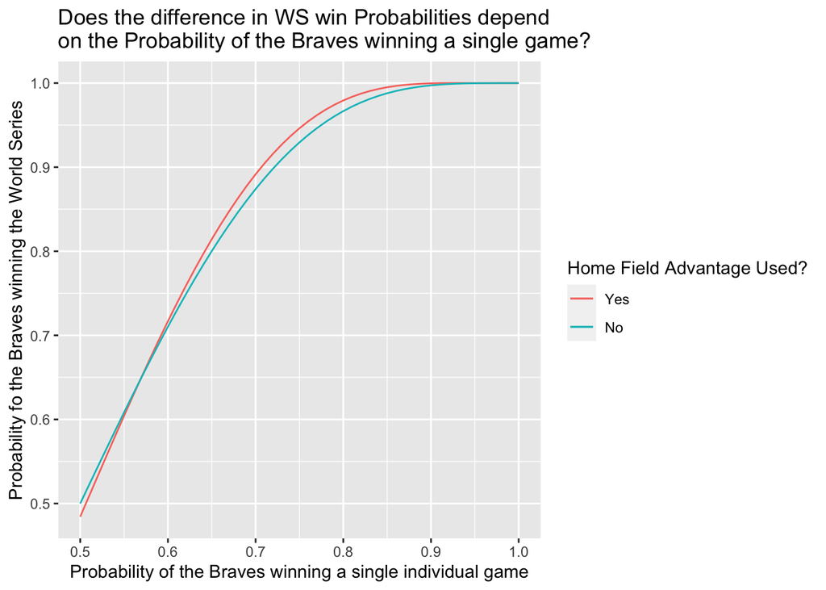

```r
set.seed(101620)

var_pb <- seq(from = .50, to = 1, .01) # vector of Brave win probability values
adv_var_prob = NA # vector of WS win probabilities using home field advantage

for(i in 1:length(var_pb)){
  adv_var_prob[i] = analytical_ws(hfi, advantage_multiplier, pb = var_pb[i])[1,2] # use the analytical method
}

no_adv_var_prob = NA # vector of WS win probabilities NOT using home field advantage

for(i in 1:length(var_pb)){
  no_adv_var_prob[i] = analytical_ws(hfi, no_adv_multiplier, pb = var_pb[i])[1,2] # use the analytical method
}

library(ggplot2)
adv_var_prob <- as.numeric(unlist(adv_var_prob))
no_adv_var_prob <- as.numeric(unlist(no_adv_var_prob))

bonus1 <- data.frame(probability = var_pb, advatange_win_prob = adv_var_prob, no_advatange_win_prob = no_adv_var_prob) # cretae data frame
ggplot(bonus1) +
  geom_line(aes(x = var_pb, y = adv_var_prob, col = "adv_var_prob" )) +
  geom_line(aes(x = var_pb, y = no_adv_var_prob, col = "no_adv_var_prob")) +
  labs(
    x = "Probability of the Braves winning a single individual game",
    y = "Probability fo the Braves winning the World Series",
    title = "Does the difference in WS win Probabilities depend
on the Probability of the Braves winning a single game?"
  ) +
  scale_color_discrete(name = "Home Field Advantage Used?", labels = c("Yes", "No"))
```

As seen before, increasing the win probability of a single game will also increase the probability of winning the World Series. What surprised me was that despite the Braves playing more games away from home, the advantage multiplier actually World Series probability surpassed the no home field advantage probability. I think could be due to the fact that the Braves could win the World Series in less games actually causing them to play more home games, thus increasing the probability.

## 2.5 Bonus 2

Does the difference in probabilities (with vs without home field advantage) depend on the advantage factor? (The advantage factor in PBH and PBA is the 1.1 multiplier that results in a 10% increase for the home team.)

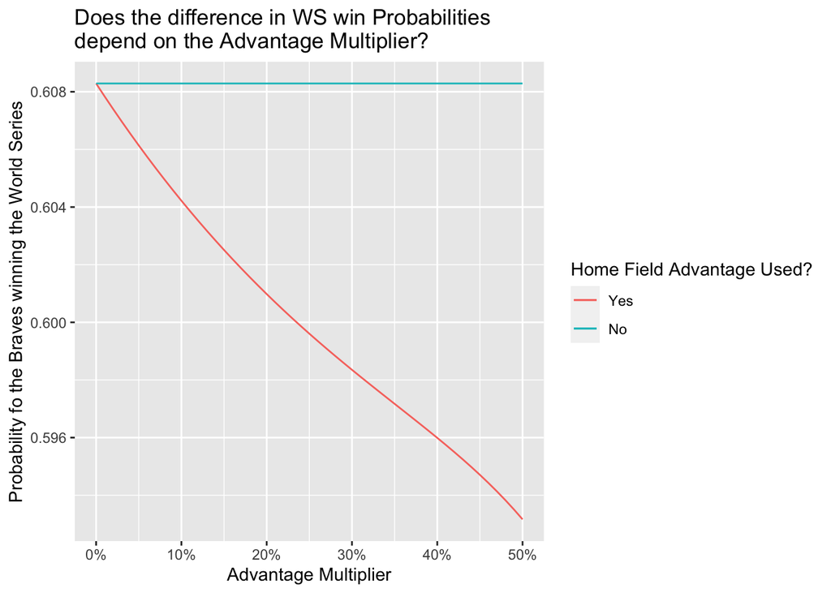

```r
set.seed(101820)


var_adv_mult =  seq(1, 1.5, 0.01) # vector of advantage multipliers
adv_var_probx = NA # vector of WS win probabilities using home field advantage

for(i in 1:length(var_adv_mult)){
  adv_var_probx[i] = analytical_ws(hfi, var_adv_mult[i], pb)[1,2] # use the analytical method
}

no_adv_var_probx = NA # vector of WS win probabilities NOT using home field advantage

for(i in 1:length(var_adv_mult)){
  no_adv_var_probx[i] = analytical_ws(hfi, no_adv_multiplier, pb)[1,2] # use the analytical method
}

adv_var_probx <- as.numeric(unlist(adv_var_probx))
no_adv_var_probx <- as.numeric(unlist(no_adv_var_probx))

bonus2 <- data.frame(advantage_multiplier = var_adv_mult, advatange_win_prob = adv_var_probx, no_advatange_win_prob = no_adv_var_probx) # create a data frame
ggplot(bonus2) +
  geom_line(aes(x = var_adv_mult, y = adv_var_probx, col = "adv_var_prob" )) +
  geom_line(aes(x = var_adv_mult, y = no_adv_var_probx, col = "no_adv_var_prob")) +
  labs(
    x = "Advantage Multiplier",
    y = "Probability fo the Braves winning the World Series",
    title = "Does the difference in WS win Probabilities
depend on the Advantage Multiplier?"
  ) +
  scale_color_discrete(name = "Home Field Advantage Used?", labels = c("Yes", "No")) +
  scale_x_continuous(labels = function(x){paste0((x-1) * 100, '%')})
```

This is the graph I was expecting as the line not using home field advantage would be flat and the line using the advanatge multiplier would be heavily decreasing. This is due to the fact that the Braves would be playing more away games than home games, resulting in the home field advantage multiplier casuing a negative affect in the Braves probabiity of winning the World Series.

# 3 Conclusions

The main takeaways that stood out to me involved the advantage multiplier. The advantage multiplier only benefits the team playing more home games, while also causing a higher degree of error in simulations. By increasing a game win probability by 10% for home field advantage, the Braves World Series win probability decreased by 0.4% in the analytical calculations and 0.2% in the simulations. When there was no advantage multiplier, the difference between the analytical and simulation calculations was a minuscule 0.05%. Therefore, with a home field advantage of 10%, the advantage multiplier did not play a significant role in affecting the Braves chances of winning the World Series.